# ETC1010-5510: Introduction to Data Analysis

Assignment 2

In this assignment, we are going to study test scores from the The Programme for International Student Assessment (PISA) scheme, which tests 15-year-old students across all states in Australia. You can find the data sets and a code book for the assignment in the *Data* folder. Broadly speaking, PISA measures scholastic ability across three categories: science, reading and math.

The goal of this analysis is to understand if differences exist between PISA testing scores across various dimensions, such as income, school type, extra-curricular activities and gender.

**Please ensure that the report knits properly into html and all the R code and R outputs are visible in the final knitted report.** **You will need to save your rendered html document into a pdf file (you can use your internet browser to print your html file into a pdf file) and upload that pdf file into Moodle for submission.**

**This is an individual assignment and you must use R code to answer all the questions. Make sure that you have your messages and warnings turned off before you submit the assessment (see lines 15-17 of this Rmd file) and echo = FALSE set for the R code chunk where you load your libraries.**

## Question 1: Read in the pisa data set (1pt) and show the first 4 rows the data frame (1pt).

```r
pisa <- read_csv('data/pisa_au.csv')
head(pisa,4)
```

```
## # A tibble: 4 × 44
##   state schtype yr    birthmonth birthyr gender  desk  room computer internet
##   <chr> <chr>   <chr>      <dbl>   <dbl> <chr>  <dbl> <dbl>    <dbl>    <dbl>
## 1 QLD   Gov     Y10           10    1999 female     1     2        1        1
## 2 QLD   Gov     Y10            2    2000 female     2     1        1        1
## 3 QLD   Gov     Y10            3    2000 female     1     1        1        1
## 4 QLD   Gov     Y10            7    1999 female     1     1        1        1
## # ℹ 34 more variables: solarpanels <chr>, tvs <dbl>, cars <dbl>,
## #   music_instr <dbl>, books <dbl>, birthcnt <dbl>, mother_birthcnt <dbl>,
## #   father_birthcnt <dbl>, test_anxiety <dbl>, ambitious <dbl>,
## #   prefer_team <dbl>, make_friends_easy <dbl>, tardy <dbl>, science_fun <dbl>,
## #   breakfast <dbl>, work_pay <dbl>, sport <dbl>, internet_use <dbl>,
## #   install_software <dbl>, outhours_study <dbl>, math_time <dbl>,
## #   read_time <dbl>, science_time <dbl>, belong <dbl>, anxtest <dbl>, …
```

## Question 2: Calculate the average `math`, `science` and `read` score across states. (2pts) Create a table where you display the top 3 states that have highest average in `math`. (2pts)

```r
mean_scores <- pisa %>%
  group_by(state) %>%   #1pt
  summarise(mean_math = mean(math, na.rm = TRUE),mean_science = mean(science, na.rm = TRUE),mean_read = mean(read, na.rm = TRUE))  # 1pt
```

```r
mean_scores %>%
  arrange(-mean_math) %>%  #1pt
  head(3)   #1pt
```

```
## # A tibble: 3 × 4
##   state mean_math mean_science mean_read
##   <chr>     <dbl>        <dbl>     <dbl>
## 1 ACT        501.         523.      511.
## 2 WA         496.         512.      499.
## 3 VIC        495.         509.      504.
```

```r
top_marks_1999 <- pisa %>%
  group_by(schtype) %>%  #0.5pt
  dplyr::filter(gender=="female", birthyr == 1999) %>%  #0.5pt
  summarise(mean_math = mean(math, na.rm = TRUE),mean_science = mean(science, na.rm = TRUE),mean_read = mean(read, na.rm = TRUE)) %>%   #0.5pt
  arrange(-mean_math)  #0.5pt
```

```r
top_marks_2000 <- pisa %>%
  group_by(schtype) %>%  #0.5pt
  dplyr::filter(gender=="female", birthyr == 2000) %>%  #0.5pt
  summarise(mean_math = mean(math, na.rm = TRUE),mean_science = mean(science, na.rm = TRUE),mean_read = mean(read, na.rm = TRUE)) %>%   #0.5pt
  arrange(-mean_math)
```

## Question 4: For the states of VIC, NSW, and QLD, using `geom_density` plot the distribution of marks in `read` by gender using a faceted plot to capture school type (2pt). Which combination of states/schools do female students perform worst in? (2pt).

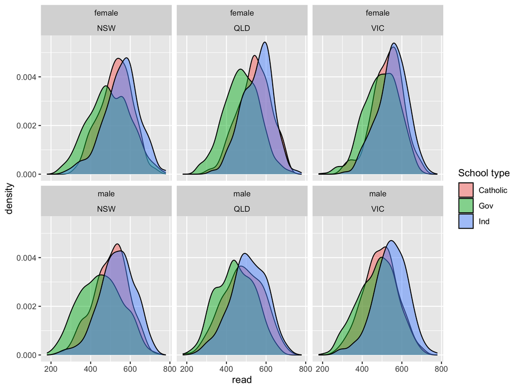

```r
pl1 <- ggplot(data=pisa %>% filter(state %in% c('VIC','NSW','QLD')), aes(x=read,fill=schtype)) +
  geom_density(alpha=0.5) +
  facet_wrap(~gender+state) +
  labs(fill='School type')
print(pl1)
```

According to the above density plot, **Government schools in the state of New South Wales (NSW)** were observed to report **low read scores for females**.

## Question 5: First, create a data frame called *pisa_filtered* that excludes observations with missing values **among any variable** (2pt). Then, calculate a new variable called *tot_score* that is the sum of the math/science/reading scores and add this to the data frame *pisa_filtered* (1pt); in addition, calculate a new variable *tot_time* as the sum of the math_time/read_time/science_time and add this new variable to the data frame *pisa_filtered* (1pt). Using a `geom_point()` describe the relationship between *tot_time* (x-axis) and *tot_score* (y-axis). (2pts)

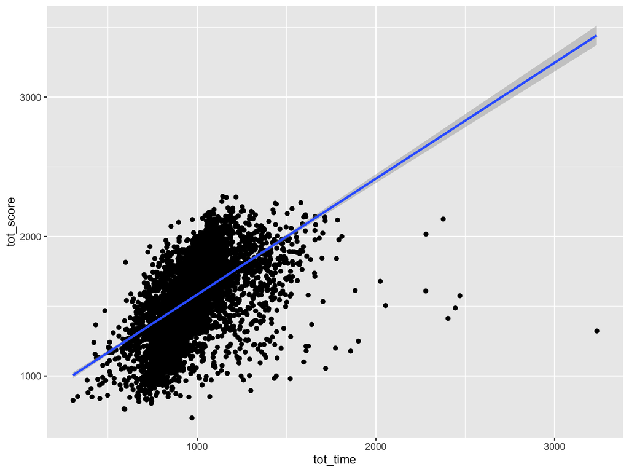

```r
pisa_filtered <- drop_na(pisa) #(2pt)


pisa_filtered<-pisa_filtered %>%
  dplyr::mutate(tot_score = math+science+read) %>%   #1pt
  dplyr::mutate(tot_time = math+science_time+read_time)   #1pt

pisa_filtered %>%  ggplot(aes(y=tot_score,x=tot_time))+geom_point() + geom_smooth(method='lm' ) #(2pt)
```

## Question 6. Let us try and understand the importance of extracurricular activities on marks. Which category of `music_instr` has the highest median score in reading, math, and science. Present your results as a table.(2pt) Looking at the table, what can you conclude about the usefullness of musical instruments on test scores? (1pt).

```r
extra_curr <- pisa_filtered %>% group_by(music_instr) %>% summarise(Median_tot_score =median(tot_score)) %>% arrange(-Median_tot_score)
extra_curr %>% kable(caption = 'Music instrument category for highest median total scores',booktabs = TRUE) %>%
kable_styling(bootstrap_options = c("bordered","hover"))
```

Music instrument category for highest median total scores

| music_instr | Median_tot_score |
| --- | --- |
| 4 | 1641.615 |
| 3 | 1578.802 |
| 2 | 1544.328 |
| 1 | 1485.898 |

The above table shows that the **median total score is higher for students who have learnt more number of musical instruments**. Hence, musical instruments are indeed **important** for total scores.

## Question 7: Describe the relationship between median scores and music instruments (1pt)? Is the effect the same for both genders? (2pt)

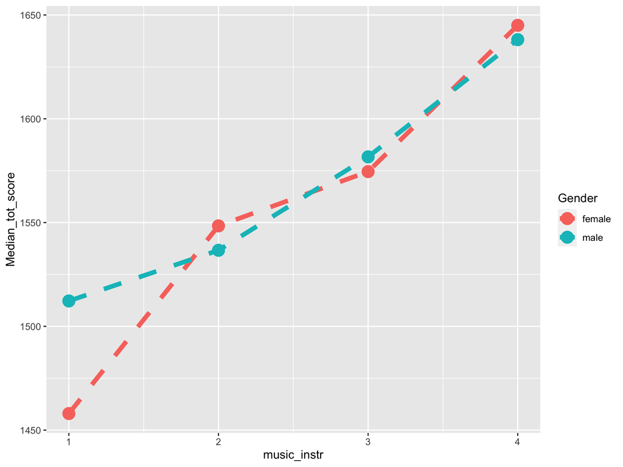

```r
extra_curr_gender <- pisa_filtered %>% group_by(music_instr,gender) %>% summarise(Median_tot_score =median(tot_score)) %>% arrange(-Median_tot_score)
pl2 <- ggplot(data= extra_curr_gender,aes(x=music_instr,y=Median_tot_score,color=gender)) + geom_line(size=2,linetype='dashed') + geom_point(size=5) + labs(color='Gender')
print(pl2)
```